# Tema 03 - Datos: Tratamiento, Limpieza y Preparación

De datos en bruto a información útil para decidir con `tidyverse`

Pedro Albarrán

Dpto. de Fundamentos del Análisis Económico. Universidad de Alicante

Henry Redondo

# Introducción. Datos Ordenados

## ¿Qué es una fila en cada tabla?

**RetailCorp**, cadena con 12 tiendas en España, nos manda las **mismas** ventas de enero y febrero de 2023 en tres formas distintas:

**(A)**

| id_venta | id_tienda | mes | total |
| --- | --- | --- | --- |
| 222 | 1 | 1 | 252,6 |
| 83 | 2 | 1 | 757,3 |
| 54 | 2 | 2 | 232,1 |
| 406 | 2 | 2 | 325,6 |

**(B)**

| id_tienda | mes | ingresos |
| --- | --- | --- |
| 1 | 1 | 14.674 |
| 1 | 2 | 7.668 |
| 2 | 1 | 10.502 |
| 2 | 2 | 10.355 |

**(C)**

| id_tienda | mes_1 | mes_2 |
| --- | --- | --- |
| 1 | 14.674 | 7.668 |
| 2 | 10.502 | 10.355 |

**En parejas, 3 minutos:**

1. ¿Qué es **una fila** en (A)? ¿y en (B)? ¿y en (C)?: ¿una venta? ¿una tienda-mes? ¿una tienda?
2. ¿Con cuál se responde “¿cuánto vendió la tienda 1 en febrero?” sin calcular nada?
3. En (C), ¿`mes_1` es una **variable** o es un **valor** de la variable *mes*?

## ¿Y esta columna es una variable?

Un gerente nos envía este Excel:

| tienda | ventas_ene | ventas_feb |
| --- | --- | --- |
| Madrid Centro | 14.674 € | 7.668 € |
| Barcelona Diagonal | 10.502 € | 10.355 € |
| **Total** | **25.176 €** | **18.023 €** |

**En parejas, 3 minutos:** ¿qué falla en cada punto?

1. La fila `Total`: ¿es una observación **del mismo tipo** que las otras dos?
2. La columna `ventas_ene`: ¿es *una* variable o son dos cosas pegadas (mes y valor)?
3. La celda `14.674 €`: ¿es un número o un texto? ¿podemos sumarla?

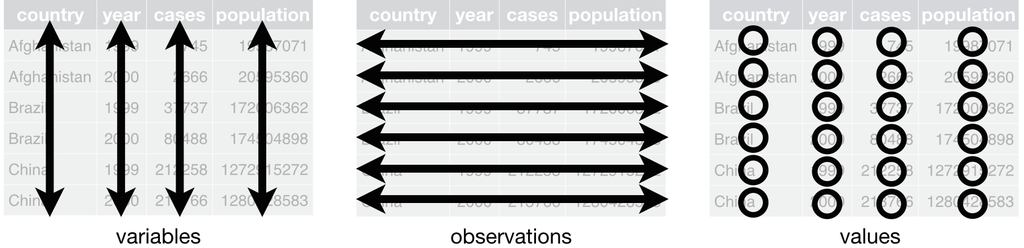

Datos **ordenados** (“tidy”):

1. cada columna, una **variable**
2. cada fila, una **observación** (todas al mismo nivel)
3. cada celda, un **valor**

```r
load("data/retail_data.RData")
```

- El 80% del tiempo del analista es [trabajo “sucio”](https://www.nytimes.com/2014/08/18/technology/for-big-data-scientists-hurdle-to-insights-is-janitor-work.html) de limpieza y preparación; `tidyverse` está pensado para trabajar con datos ordenados

# Transformación de datos (una tabla)

## Funciones de transformación de datos

- La mayoría de operaciones pueden realizarse combinando 5 “verbos”:
  1. `select()`: selecciona columnas (variables)
  2. `filter()`: filtra (extraer) filas
  3. `mutate()`: crea nuevas columnas
  4. `arrange()`: ordena filas
  5. `summarize()`: crea resúmenes de la tabla
  - Más la tubería `%>%` o `|>`
  - y `group_by()`
- NOTA: las funciones auxiliares (elegir columnas por patrón, contar, recodificar, fechas, etc.) están en el Anexo: chuleta de funciones auxiliares; se consulta cuando hace falta, no se estudia.
- Todos tienen como primer argumento un *data frame*, los siguientes describen qué hacer (con columnas o filas) y devuelven otro *data frame*

## 1. `select()`

- **Selecciona variables** por nombres o posiciones de columnas, separados por comas

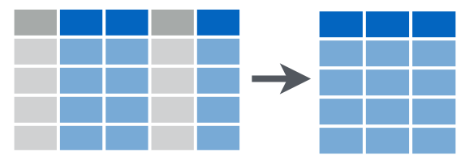

- Ej., un analista solo necesita información básica de ventas

```r
select(ventas, id_venta, fecha, id_tienda, id_producto, total)

select(ventas, 1:2, 5, 4, 12)
```

## 2. `filter()`

- Conserva filas en las que una *condición lógica* (o varias separadas por comas) es verdadera

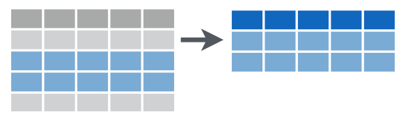

- **Caso de Uso:** Gerente quiere analizar ventas específicas con determinadas características

```r
ventas_top      <- filter(ventas, total > 1000)

ventas_ene_2024 <- filter(ventas, año == 2024, mes == 1)

ventas_mad_bcn  <- filter(ventas, id_tienda %in% c(1, 2))

ventas_premium  <- filter(ventas,
                     total > 1000 & descuento_porcentaje == 0)
```

## Encadenando operaciones con tuberías: `%>%` o `|>`

- Las operaciones encadenadas crean objetos intermedios o no son legibles

```r
ventas_top        <- filter(ventas, total > 1000)
ventas_top_markt  <- select(ventas_top,
                       fecha, id_cliente, id_producto, total)

ventas_top_markt <- select(filter(ventas, total > 1000),
                      fecha, id_cliente, id_producto, total)
```

- `datos %>% filter(condicion)` equivale a `filter(datos, condicion)`
- El anidamiento con tuberías sigue el flujo natural de lectura
  - Toma una tabla y pásala a un comando que acepta y produce un *data frame*
  - Toma la nueva tabla resultante y pásala a otro comando

```r
ventas_top_markt <- ventas |>
                     filter(total > 1000) |>
                     select(fecha, id_cliente, id_producto, total)
```

## 3. `mutate()`

- Crea o modifica variables mediante una *fórmula* a partir de otras columnas

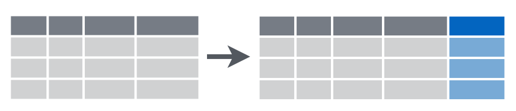

```r
ventas2 <- ventas |>
  mutate(
    precio_final_unitario = total / cantidad,
    es_inicio_mes         = day(fecha) <= 7
  )
```

- Funciones para operar con fechas (usando `lubridate`)

```r
ventas_tiempo <- ventas |>
  mutate(
    fecha_completa = as.Date(fecha),  # tipo de objeto "fecha"
    semana_año = week(fecha),
    nombre_mes = month(fecha, label = TRUE),
    dias_desde_venta = Sys.Date() - fecha
  )
```

## 4. `arrange()`

- re-ordena las filas de un *data frame* (todas las columnas)
  - en orden ascendente (por defecto) o descendente con `desc()`

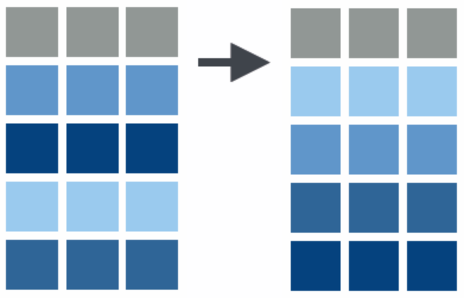

```r
ventas |>
  arrange(desc(total)) |> slice(5) |>
  select(id_venta, fecha, total)
```

- Ordenamientos **múltiples**: ordena por la primera variable y luego, en caso de empate, por la siguiente, etc.

```r
ventas |>
  arrange(id_tienda, desc(total)) |>
  select(id_tienda, id_venta, total)
```

## 5. `summarize()`

- Crea un nuevo conjunto de datos de **una sola fila**, con variables nuevas de un solo valor que resumen los datos completos

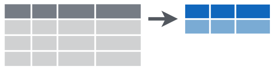

- *Caso de Uso:* KPIs para el dashboard ejecutivo

```r
KPIs <- ventas |>
  summarize(
    total_ventas       = n(),           # Volumen (núm. de filas)
    ingresos_totales   = sum(total),    # Ingresos
    ingresos_promedio  = mean(total),
    ingresos_mediano   = median(total),
    descuento_promedio = mean(descuento_porcentaje), # Descuentos
    descuento_total    = sum(descuento_aplicado),
    unidades_vendidas  = sum(cantidad),             # Productos
    clientes_unicos    = n_distinct(id_cliente)     # Clientes
                         # (núm. de filas distintas)
  )
```

## `group_by()`: Análisis por Grupos

- Cambia el alcance: *cada función* actúa dentro de grupos, no sobre toda la tabla
- Ejemplo: encontrar la fecha con la mayor venta por tienda

```r
ventas |> group_by(id_tienda) |>
  arrange(desc(total)) |>
  slice(1) |>                     # Fila 1 (de cada grupo)
  select(id_tienda, fecha, total)
```

- `group_by()` + `summarize()` = cambia el nivel de análisis, **agregando**, p.e., de transacciones a tiendas, productos, etc.
  - En Excel: *Tablas dinámicas*, *AGRUPARPOR()* (y *SUMAR.SI*/*SUMIF*)

```r
ventas                             # tabla a nivel de transacción
ventas |>
  summarize(ingresos = sum(total)) # resumen global
ventas |>
  group_by(id_tienda) |>
  summarize(ingresos = sum(total)) # resumen por tienda
                                   # tabla a nivel de tienda
```

## `group_by()` (cont.)

- `group_by() + summarize()` reduce filas: nueva tabla agregada a nivel de los grupos

```r
tabla_sum <- ventas |> group_by(id_tienda) |>
  summarize(ingresos = sum(total))
```

- `group_by() + mutate()` mantiene filas: añade columnas calculadas por grupo a nivel de la tabla original

```r
tabla_mut <- ventas |> group_by(id_tienda) |>
  mutate(ingresos = sum(total))
```

- Ejemplo: Porcentaje de las ventas que representa cada transacción

```r
ventas |> group_by(id_tienda) |>
  mutate(
    ventas_tienda = sum(total),
    pct_de_ventas = total / ventas_tienda * 100
  )
```

## `ungroup()`

- **IMPORTANTE:** No olvidar `ungroup()` o `.groups = "drop"` después de terminar operaciones agrupadas
- Cálculo de Porcentajes Globales: sin desagrupar, el segundo `sum(total)` suma *por tienda* → siempre da 100%

```r
ventas |>
  group_by(id_tienda) |>
  mutate(ventas_tienda = sum(total)) |>
  ungroup() |>
  mutate(porcentaje = ventas_tienda / sum(total) * 100)

# `.groups = "drop"` es de summarize(), NO de mutate()
ventas |>
  group_by(id_tienda) |>
  summarize(ventas_tienda = sum(total), .groups = "drop") |>
  mutate(porcentaje = ventas_tienda / sum(total) * 100)
```

## PRÁCTICA en clase (1): porcentajes que siempre dan 100

- Con la tabla `ventas` y **solo con lo visto hasta aquí**:
  1. Calcula los ingresos de 2023 de **cada tienda** y el **porcentaje** que representan sobre los ingresos totales de la cadena en 2023
  2. ¿Qué tienda tiene el porcentaje mayor? ¿Cuánto es?
  3. Un compañero propone este código para (a). Ejecútalo: ¿qué devuelve? ¿por qué?

```r
ventas |>
  filter(año == 2023) |>
  group_by(id_tienda) |>
  mutate(pct = total / sum(total) * 100) |>
  summarize(pct_tienda = sum(pct))
```

## Operaciones adicionales de limpieza

- El informe de un gerente trae dos variables pegadas en una columna: `separate()` divide, `unite()` combina

```r
informe <- tibble(tienda_region = c("Madrid Centro/Centro",
                                    "Alicante Playa/Levante"),
                  ventas        = c(14674, 9310))

informe |>
  separate(tienda_region, into = c("tienda", "region"), sep = "/")

informe |>
  separate(tienda_region, into = c("tienda", "region"), sep = "/") |>
  unite(etiqueta, region, tienda, sep = " - ")
```

- Nombres de columna con espacios o símbolos: acento invertido (mejor, renombrarlos)

```r
datos_problema |>
  rename(nombre_producto = `Nombre Producto`,
         precio_euros    = `Precio (€)`)
```

# Transformación de Datos: Pivotar

## ¿Qué es una fila aquí? (otra vez)

**Formato ANCHO** (informe de los gestores)

| tienda | Q1 | Q2 | Q3 | Q4 |
| --- | --- | --- | --- | --- |
| Madrid | 145 | 158 | 151 | 169 |
| Barcelona | 152 | 164 | 156 | 175 |
| Valencia | 138 | 151 | 149 | 162 |

```r
ventas_ancho
```

**Formato LARGO** (los mismos datos)

| tienda | trimestre | ventas |
| --- | --- | --- |
| Madrid | Q1 | 145 |
| Madrid | Q2 | 158 |
| Madrid | Q3 | 151 |
| Madrid | Q4 | 169 |
| Barcelona | Q1 | 152 |
| … | … | … |

**En parejas, 3 minutos:**

1. ¿Qué es **una fila** en la tabla ancha? ¿y en la larga? ¿Cuántas filas tiene cada una?
2. En la ancha, `Q1` ¿es una variable o un valor? ¿Dónde está el trimestre en cada tabla?
3. ¿Con cuál se puede responder “¿qué trimestres superan 160 en ventas?” con un `filter()`?

## `pivot_longer()`: girar de ancho a largo

- Girar para analizar los datos

```r
ventas_largo <- ventas_ancho |>
  pivot_longer(
    cols = Q1:Q4,
    names_to = "trimestre",
    values_to = "ventas"
  )
```

1. tabla a cambiar de forma
2. nombres o índices de las columnas a girar (representan valores)
3. nombre para la nueva variable que tendrá, como valores, las columnas a girar
4. nombre para la nueva variable que tendrá como valores las antiguas celdas

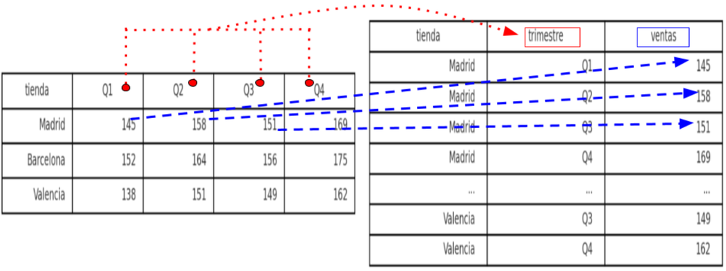

## `pivot_wider()`: girar de largo a ancho

- Girar para crear tabla de presentación

```r
ventas_largo |>
  pivot_wider(
    names_from = trimestre,
    values_from = ventas
  )
```

1. tabla a cambiar de forma
2. nombre de la variable cuyos valores dan nombre a las nuevas columnas
3. nombre de la variable de cuyas celdas toman los valores las nuevas columnas

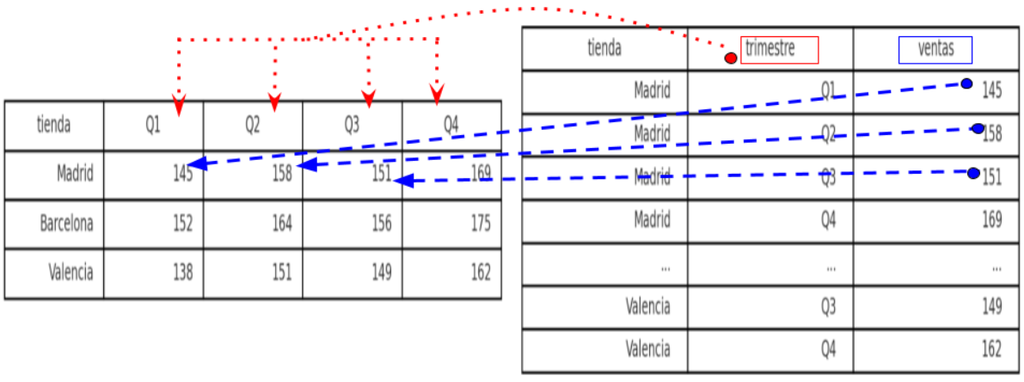

## PRÁCTICA en clase (2): girar para poder responder

- Partimos de `ventas_ancho` (3 tiendas, columnas `Q1` a `Q4`):
  1. ¿En qué trimestre vendió más **la cadena entera**? ¿Cuánto?
  2. Prepara la **tabla de presentación** para el informe: una fila por tienda, los trimestres en columnas y una última columna `Total` con la venta anual de cada tienda
  3. ¿Con qué formato has hecho (a)? ¿Y (b)? ¿Por qué no al revés?

# Datos Relacionales

## Por Qué Múltiples Tablas

- Analizar datos suele implicar múltiples tablas
  - diferentes orígenes: ej., dptos. de empresa (personal, ventas, almacén)
  - almacenamiento más eficiente: elementos “similares” dentro de una tabla y diferentes entre ellas
- Para poder combinar información los datos deben ser relacionales: cada par de tablas están relacionadas mediante identificadores comunes llamados **claves**
  - Primaria (o interna): identifican de forma única cada observación en una tabla. Puede ser una sola variable o múltiples
  - Secundaria (o externa): señala a la clave primaria de otra tabla
- Una clave primaria y su externa asociada en otra tabla forman una relación: de uno-a-muchos, de uno-a-uno, de muchos-a-muchos, de muchos-a-uno
- Antes de unir hay que saber **qué es una fila** en cada tabla: es lo que decide si la unión añade información o inventa filas

## Tres tablas a tres niveles distintos

- La dirección pregunta: **¿cuánto facturó cada tienda en 2023, a los precios vigentes en cada fecha, y cómo va frente a su objetivo mensual?**

| tabla | una fila es… | filas | clave primaria |
| --- | --- | --- | --- |
| `ventas` | una venta | 5.000 | `id_venta` |
| `precios` | un producto en un **periodo de vigencia** | 276 | `id_producto` + `desde` |
| `objetivos` | una tienda en un **mes** de 2023 | 144 | `id_tienda` + `año` + `mes` |

```r
precios     # histórico de precios: productos solo guarda el precio de HOY
objetivos   # objetivo de facturación de cada tienda en cada mes de 2023
```

- Ninguna de las dos se empareja con `ventas` una fila con una fila. Lo que dice si la unión está bien no es el nombre de la función: es el **número de filas** antes y después

## Uniones de transformación

- Añaden **nuevas variables** a una tabla desde *filas coincidentes* en otra.
- Tenemos estos [datos](https://raw.githubusercontent.com/albarran/00datos/main/DosTablas.xlsx).
- ¿Cómo conseguimos unirlos adecuadamente en R y en Excel?

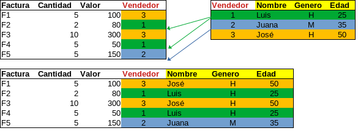

- Con `cbind()` o `bind_columns()` o copiando y pegando en Excel: nuevas columnas para filas en el mismo orden

```r
tabla1 <- import("data/DosTablas.xlsx", sheet = 1)
tabla2 <- import("data/DosTablas.xlsx", sheet = 2)
union  <- inner_join(tabla1, tabla2, by = "Vendedor")
```

## ¿Qué unión necesito aquí?

**Quiero la región de cada venta y no perder ni una venta** (hay tiendas sin ventas, me da igual)

```r
# 5000 filas: las mismas que ventas
ventas |> left_join(tiendas, by = "id_tienda")
```

**Quiero solo las ventas atendidas por un empleado** (las ventas online no tienen `id_empleado`)

```r
# 4850 filas: se van 150 ventas online
ventas |> inner_join(empleados, by = "id_empleado")
```

**Quiero el margen medio de TODAS las categorías del catálogo**, aunque alguna no tenga productos

```r
productos |>
  mutate(margen = precio - costo) |>
  right_join(categorias, by = c("id_categoria" = "categoria"))
```

**Quiero cuadrar el listado de RRHH con el de bonos** sin perder a nadie de ninguna de las dos listas

```r
empleados |>
  full_join(promociones_empleado,
            by = c("id_tienda"    = "cod_tienda",
                   "cod_empleado" = "cod_empleado"))
```

- Antes de unir, **decidir** qué filas deben quedar y contarlas después: si el número cambia sin querer, la unión está mal

## El precio no vive en la venta

- `ventas` registra unidades; `precio_unitario` es el precio **de hoy** del catálogo. El del producto 7 subió el 1-sep-2023

| id_producto | precio | desde | hasta |
| --- | --- | --- | --- |
| 7 | 174,58 | 2020-01-01 | 2021-12-31 |
| 7 | 188,55 | 2022-01-01 | 2023-08-31 |
| 7 | 211,18 | 2023-09-01 | 2024-12-31 |

- Unimos por la clave, `id_producto`, y **contamos las filas antes y después**

```r
ventas_2023 <- ventas |> filter(año == 2023)
nrow(ventas_2023)                                               # 2000

ventas_2023 |> left_join(precios, by = "id_producto") |> nrow()  # 3714
```

- 1.714 filas que no existieron nunca: cada venta se ha copiado tantas veces como periodos de precio tiene su producto

## El precio no vive en la venta (cont.)

- Una venta del 19-ago-2023 casa con los **tres** periodos; solo uno estaba vigente

```r
ventas_2023 |> filter(id_venta == 3662) |>
  select(id_venta, fecha, id_producto, cantidad) |>
  left_join(precios, by = "id_producto")   # 3 filas: 174,58 / 188,55 / 211,18
```

- La condición que faltaba es la fecha: la clave es `id_producto` **y** el periodo

```r
ventas_2023_precio <- ventas_2023 |>
  left_join(precios, by = "id_producto") |>
  filter(fecha >= desde, fecha <= hasta)

nrow(ventas_2023_precio)                # 2000: una fila por venta, otra vez
sum(is.na(ventas_2023_precio$precio))   # 0: ninguna venta sin precio vigente
```

- Red de seguridad: `relationship` **detiene** la unión en vez de duplicar

```r
ventas_2023 |> left_join(precios, by = "id_producto",
                         relationship = "many-to-one")
# Error: Each row in `x` must match at most 1 row in `y`
```

## ¿Cuánto facturó cada tienda en 2023?

```r
facturacion_tienda <- ventas_2023_precio |>
  group_by(id_tienda) |>
  summarize(facturacion = sum(cantidad * precio), .groups = "drop") |>
  arrange(desc(facturacion))
```

| id_tienda | facturación (€) |
| --- | --- |
| 4 | 126.255,61 |
| 2 | 114.491,31 |
| 9 | 113.042,98 |
| … | … |
| 11 | 90.444,44 |

- Total de la cadena: **1.251.667 €**
- Con el precio del catálogo habrían salido 1.268.551 €
- La diferencia, **16.884 €**, es un 1,3%: poco como porcentaje, bastante en la cuenta de resultados

## Sobre el argumento `by`

- Las claves, es decir, las variables que relacionan ambas tablas, se indican con
  - `by = "varX"`, cuando la clave es una variable
  - `by = c("varX", "varY")`, cuando son varias variables: deben coincidir **todas**
- Si los nombre son distintos en cada tabla, se empareja `x1` en la primera con `y1` en la segunda con `by = c("x1" = "y1", "x2" = "y2")`
- `objetivos` no se identifica con una sola variable: hace falta tienda **y** mes

```r
# 12 filas: no vale como clave
objetivos |> count(id_tienda) |> filter(n > 1)
# 0 filas: esta SI es la clave
objetivos |> count(id_tienda, año, mes) |> filter(n > 1)
```

- Ej., calcular el bono medio de los Vendedores

```r
empleados |> filter(puesto == "Vendedor") |>
  left_join(promociones_empleado,
            by = c("id_tienda" = "cod_tienda",
                   "cod_empleado") ) |>
  pull(monto_bono) |> mean(na.rm = T)   # 501,79 euros
```

## Dos columnas, una sola clave

- `promociones_empleado` no guarda el identificador global del empleado: guarda su número **dentro de su tienda**, que es como numeran las cadenas de verdad. El 3 de Madrid y el 3 de Valencia son dos personas distintas

```r
# 9 codigos repetidos: por si solo no identifica a nadie
promociones_empleado |> count(cod_empleado) |> filter(n > 1)
# 0 filas: la clave son LAS DOS columnas
promociones_empleado |> count(cod_tienda, cod_empleado) |> filter(n > 1)
```

- Unir por una sola de las dos no da error: da filas de más

```r
plantilla <- empleados |> filter(!is.na(id_tienda))
nrow(plantilla)                    # 85 empleados con tienda

# une con los bonos de otras tiendas
plantilla |>
  left_join(promociones_empleado, by = "cod_empleado") |>
  nrow()                           # 387

# la clave son las dos columnas
plantilla |>
  left_join(promociones_empleado,
            by = c("id_tienda" = "cod_tienda", "cod_empleado")) |>
  nrow()                           # 85
```

## El objetivo tampoco vive en la venta

- Tentación: unir `objetivos` a las ventas y sumar

```r
ventas_2023_precio |>
  left_join(objetivos, by = c("id_tienda", "año", "mes")) |>
  group_by(id_tienda) |>
  summarize(objetivo_anual = sum(objetivo))   # tienda 1: 1.188.300 €
```

- El objetivo anual de la tienda 1 son **92.900 €**, no 1.188.300 €

```r
objetivos |> group_by(id_tienda) |> summarize(objetivo_anual = sum(objetivo))
```

- Y sin embargo la unión **no ha duplicado ni una fila**: 2.000 antes, 2.000 después
- El objetivo de cada mes se ha copiado en todas las ventas de ese mes y `sum()` lo cuenta una vez por venta: la tienda 1 hizo 141 ventas en 2023, así que su objetivo sale casi 13 veces mayor

## Agregar primero, unir después

- Para comparar con el objetivo hay que llevar las ventas **a su mismo nivel**: tienda-mes

```r
facturacion_mes <- ventas_2023_precio |>
  group_by(id_tienda, año, mes) |>
  summarize(facturacion = sum(cantidad * precio), .groups = "drop")

nrow(facturacion_mes)    # 144 = 12 tiendas x 12 meses, el nivel de objetivos

cumplimiento <- facturacion_mes |>
  left_join(objetivos, by = c("id_tienda", "año", "mes")) |>
  mutate(cumplimiento = round(facturacion / objetivo * 100, 1))
```

| id_tienda | mes | facturación | objetivo | cumplimiento |
| --- | --- | --- | --- | --- |
| 1 | 1 | 15.336,91 | 15.600 | 98,3 |
| 1 | 2 | 7.806,36 | 8.500 | 91,8 |
| 1 | 3 | 6.366,60 | 5.700 | 111,7 |

- En el año, 7 de las 12 tiendas cumplen: la 5 es la mejor (105,0%) y la 10 la peor (96,4%)
- **La regla**: agregar hasta el nivel de la otra tabla y unir después. Al revés no da error, da un número sin sentido

## Claves duplicadas

- Si una coincidencia no es única, se generan todas las combinaciones posibles (producto cartesiano) de las observaciones coincidentes
- `id_producto` **no** es clave primaria de `precios`: 97 de los 150 productos tienen más de un periodo de precio

```r
precios |> count(id_producto) |> filter(n > 1)           # 97 filas

precios |> count(id_producto, desde) |> filter(n > 1)    # 0 filas: clave doble
```

- Comprobar la clave de la tabla que se une cuesta una línea; explicar después por qué la facturación salía un 77% mayor (2.219.322 € en vez de 1.251.667 €) cuesta bastante más
- NOTA: sólo unir cuando sea necesario y siempre usar solo filas y variables estrictamente necesarias

## PRÁCTICA en clase (3): diciembre contra el objetivo

- Con `ventas`, `precios` y `objetivos`:
  1. ¿Cuántas filas tiene `precios` y cuántos productos tienen más de un periodo de precio? ¿Cuál es su clave primaria? Compruébalo con `count()`
  2. Facturación real de **diciembre de 2023** de cada tienda, a los precios vigentes, junto a su objetivo de diciembre y el porcentaje de cumplimiento, de mayor a menor. ¿Cuántas tiendas cumplieron?
  3. Un compañero hace (b) uniendo `objetivos` **antes** de agregar. Ejecútalo: ¿por qué la tienda 1 cumple el 7,0% de su objetivo?

```r
# el código del compañero, para el apartado c)
ventas |> filter(año == 2023, mes == 12) |>
  left_join(precios, by = "id_producto") |>
  filter(fecha >= desde, fecha <= hasta) |>
  left_join(objetivos, by = c("id_tienda", "año", "mes")) |>
  group_by(id_tienda) |>
  summarize(facturacion = sum(cantidad * precio),
            objetivo    = sum(objetivo)) |>
  mutate(cumplimiento = round(facturacion / objetivo * 100, 1))
```

## Uniones de Filtrado

- Filtran las **observaciones** de la tabla de la izquierda basándose en si coinciden o no con una observación de la otra tabla
- Se tiene un subconjunto de las filas de la tabla de la izquierda
- `semi_join(x, y)` mantiene las observaciones en `x` que están en `y`

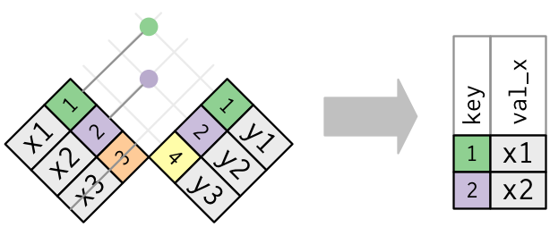

- `anti_join(x, y)` elimina las observaciones en `x` que están en `y`

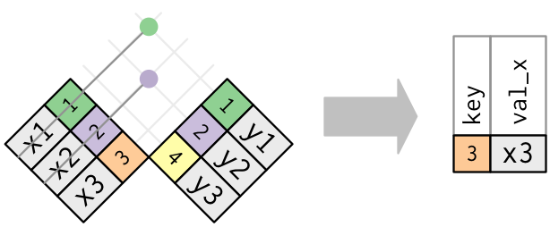

- Nota: se puede conseguir lo mismo con `inner_join()`, `full_join()`, etc. pero es ineficiente

## Uniones de Filtrado (cont.)

- Útiles para diagnosticar desajustes de uniones (qué observaciones serán emparejadas). Importante antes de unir tablas MUY grandes

```r
# empleados sin información de ventas
empleados |> anti_join(ventas,
                       by = c("id_empleado", "id_tienda")) |>
  count(id_empleado, id_tienda)
```

- Pueden ser una alternativa simple a usar `filter()` con filtrados complejos (que involucran varias variables), creando previamente tablas resumidas

  -Ej., venta promedio de los 10 productos con más cantidad vendida
- Aplicación: ¿cuántos clientes tenemos y cuántos sí han comprado?

```r
clientes |> distinct(id_cliente) |> count()
clientes |> semi_join(ventas) |> distinct(id_cliente) |> count()
```

- Aplicación: ¿qué productos NO han sido devueltos?

## PRÁCTICA en clase (4): unir sin perder (ni inventar) filas

- Con `ventas`, `tiendas` y `clientes`:
  1. Ingresos de 2023 por **región**, con el número de ventas de cada una, ordenados de mayor a menor
  2. ¿Cuántos clientes de la tabla `clientes` **no** han comprado nunca? ¿Y cuántos sí?
  3. En (a) has unido `ventas` con `tiendas`. Si por un error de carga la tienda 1 apareciera **dos veces** en `tiendas`, ¿qué le pasaría a tu respuesta? Compruébalo

```r
# bind_rows() apila las filas de dos tablas: aquí, tiendas con la 1 repetida
tiendas_mal <- bind_rows(tiendas, tiendas |> filter(id_tienda == 1))
```

## Operaciones de conjunto

- Trabajan con filas completas, comparando valores de cada variable.
- Esperan que `x` e `y` tengan las **mismas variables**, y tratan las observaciones (filas) como elementos de un conjunto.
- Útil cuando se quiere dividir un filtro complejo en piezas más simples.

```r
df1 <- tibble(x = 1:2, y = c(1, 1))
df2 <- tibble(x = c(1,1), y = 1:2)

intersect(df1, df2)     # solo filas tanto en df1 como en df2
union(df1, df2)         # filas únicas en ambas tablas
union_all(df1, df2)     # todas las filas, con duplicados
setdiff(df1, df2)       # filas en df1, pero no en df2
setdiff(df2, df1)
```

# Conclusión. Buenas prácticas

## Buenas Prácticas

- Datos Ordenados
- Código Legible y reproducible
  1. Scripts ordenados y comentados
  2. Encadenar operación con `|>` en un paso por línea
  3. Inspeccionar resultados intermedios
  4. Documentar decisiones de limpieza
  5. Nombres descriptivos de variables
  6. Guardar datos procesados
- Errores comunes
  1. No verificar claves en uniones (¿qué variables? (¿hay claves dupolicadas?))
  2. Orden de operaciones incorrecto: ej., filtrar después de `summarize()` por una variable que ya no existe

## Buenas Prácticas (cont.)

### Eficiencia:

1. Realizar transformaciones (seleccionar, filtrar, crear columnas) temprano, unir tarde

```r
ventas_2023_prod <- ventas |>
  filter(año == 2023) |>    # reduce tamaño
  left_join(productos, by = "id_producto")

ventas_2023_prod_lento <- ventas |>
  left_join(productos, by = "id_producto") |>
  filter(año == 2023)
```

2. Seleccionar solo columnas necesarias